# MECH476: Engineering Data Analysis in R

Chapter 7 Homework: Multivariate Exploratory Data Analysis

Vance Petersen

24 October, 2025

# Load packages

```
## [1] "C:/Users/Vance/OneDrive - Colostate/Desktop/Petersen---MECH476/homework"
```

# Chapter 7 Homework

In [Chapter 5](https://smogdr.github.io/edar_coursebook/eda1.html#cumulative-distribution-plot), we briefly explored data on the salaries of engineering graduates from the National Science Foundation 2017 [National Survey of College Graduates](https://www.nsf.gov/statistics/srvygrads/) from a univariate perspective. Now, let’s explore the relationships between multiple variables.

When a question asks you to make a plot, remember to set a theme, title, subtitle, labels, colors, etc. It is up to you how to personalize your plots, but put in some effort, and make the plotting approach consistent throughout the document. For example, you could use the same theme for all plots. I also like to use the subtitle as a place for the main summary for the viewer.

## Question 1: Data wrangling

Within a pipeline, import the data from the .csv file, convert all column names to lowercase text (either “manually” with `dplyr::rename()`, or use [`clean_names()` from the `janitor` package](https://rdrr.io/cran/janitor/man/clean_names.html)), convert `gender` from “numeric” to “factor”, and drop any and all observations with `salary` recorded as 0. Assign this to a dataframe object with a meaningful name.

How many observations have a 0 (zero) value for salary? Note: The last question asked you to remove these observations from the resultant data frame.

```
## [1] 15
```

What are the levels in `gender`? (Ignore the fact that the observations refer to “biological sex”, not “gender”. *Gender* is now recognized as a fluid term with more than two options; *biological sex* - what was assigned at birth - is binary term).

```
## [1] 2
```

## Question 2: Univariate EDA

Using what you learned in Chapter 5, generate basic plots and/or descriptive statistics to explore `age`, `gender`, and `salary`. List whether each variable is continuous or categorical, and explain how and why you adjusted your EDA approach accordingly.

## Question 3: Multivariate histograms

Create a histogram of `salary`, faceted by `gender`. Add `bins = 50` and `color = "lightgrey"`.

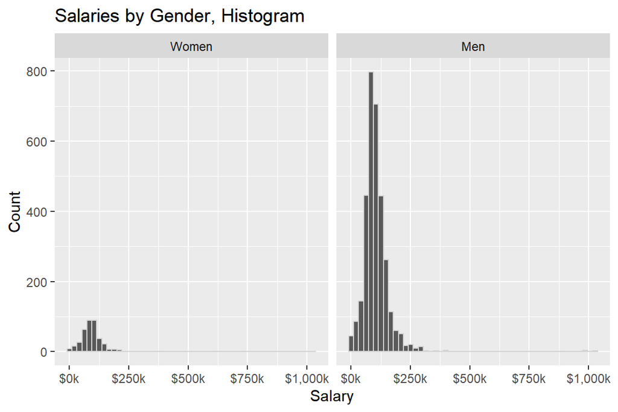

Create a histogram of `age`, faceted by `gender`. Add `bins = 50` and `color = "lightgrey"`.

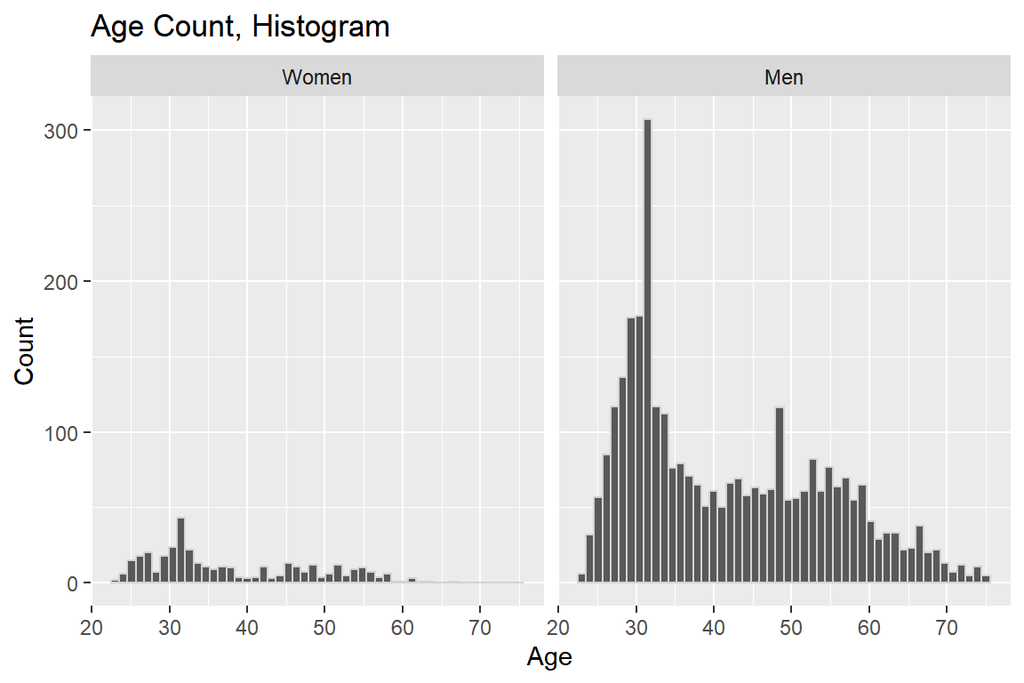

## Question 4: Multivariate boxplots

Create a boxplot of `salary`, faceted by `gender`. Use `oulier.shope = 1` to better visualize the outliers.

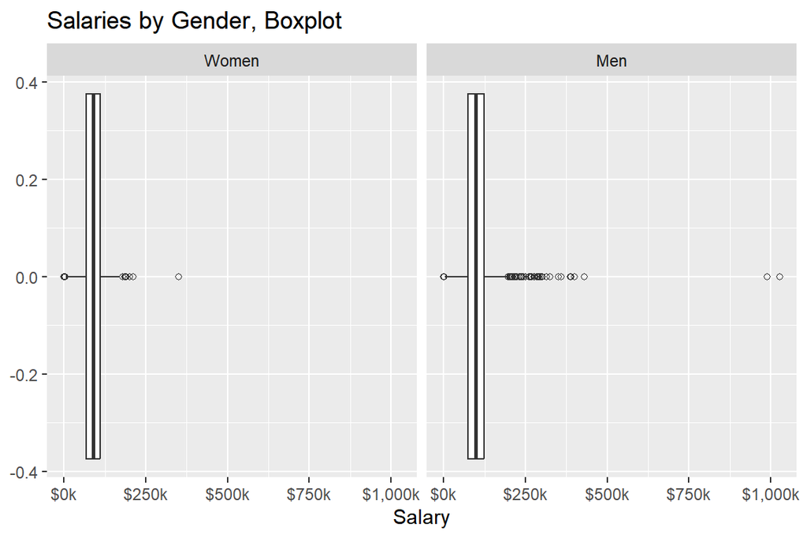

Create a boxplot of `age`, faceted by `gender`.

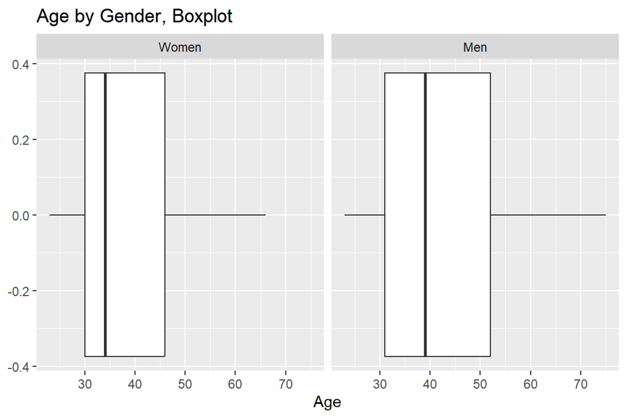

## Question 5: Scatterplot and correlation

Create a scatterplot of `age` (x-axis) and `salary`, differentiating by `gender`.

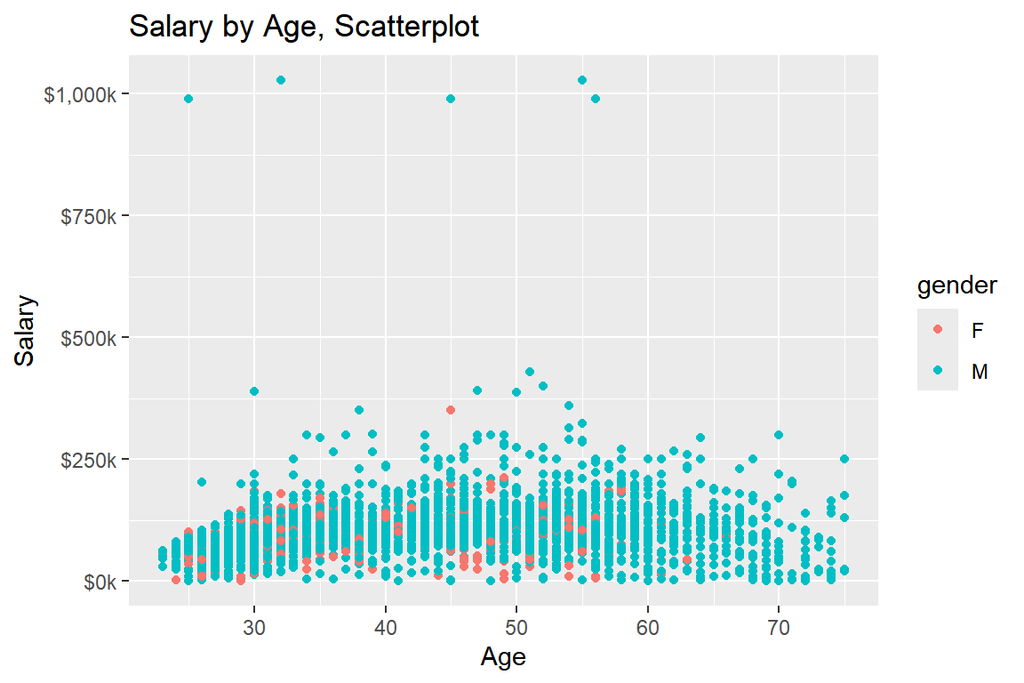

*Bonus point*: Is there a correlation between an engineer’s salary and age? What is the estimated Pearson correlation coefficient *r*? Run a formal test.

## Question 6: Cumulative distribution function

Plot the cumulative distribution function of `salary` by `gender`. Adjust the x-axis with `scale_x_log10(limits = c(5e4, 5e5))` to zoom in a bit. What do you notice about the salaries for men and women? Hint: Remember there are greater differences the farther up you go on a log scale axis.

[figure not shown]

## Question 7: Quantiles

Calculate the quantiles of `salary` by `gender`. You can either subset the data with `dplyr::filter()` and dataframe assignment, or you can group by, summarize by quantile, and ungroup.

*Bonus point*: Assign the output to a dataframe, and use inline code to call individual values when answering the following questions. Do not let R use scientific notation in the text output; check the knitted document.

```
##      salary        gender
##  Min.   :    105   F:   0
##  1st Qu.:  75000   M:3228
##  Median :  97000
##  Mean   : 104188
##  3rd Qu.: 123000
##  Max.   :1027653
```

```
##      salary       gender
##  Min.   :   140   F:373
##  1st Qu.: 68000   M:  0
##  Median : 90000
##  Mean   : 91620
##  3rd Qu.:110513
##  Max.   :350000
```

What is the difference in salary between men and women at the median?

- Median salary for women is $90,000
- Median salary for men is $97,000
- The difference at the median is $7,000

At the top percentile (maximum)?

- Maximum salary for women is $350,000
- Maximum salary for men is $1,027,653
- The difference at the maximum is $677,653

Do you think there is a salary difference by gender across the pay scale? What other information would you need to test your hypothesis?

- Yes, there is a salary difference by gender. Other information that would help could possibly be the GPAs of the ME students, and whether they graduated or not.

## Question 8: Hypothetical analysis

Think about what other variables you would like to include in a hypothetical analysis. From your perspective, what are the most important individual, family, and workforce factors related to salary—beyond gender and age?

The most important factors could be work ethic and overall smarts, evidenced by GPA, along with the familial income of the ME student, which could help visualize how big a part nepotism plays in the salaries.

## Question 9: Recreate plot

# Appendix

```r
# set global options for figures, code, warnings, and messages
knitr::opts_chunk$set(fig.width=6, fig.height=4, fig.path="../figs/",
                      echo=FALSE, warning=FALSE, message=FALSE)
# load packages for current session

library("tidyverse")
library("knitr")
library("tinytex")


getwd()
# import and tidy salary data

salaries <- read.csv("../data/ME_salaries.csv") %>% rename(salary = SALARY, age = AGE, gender = GENDER) %>% mutate(gender = as.factor(gender)) %>% filter(salary != 0)

# number of observations with salary as 0

read.csv("../data/ME_salaries.csv") %>% filter(SALARY == 0) %>% nrow()

# number of factor levels

nlevels(salaries$gender)

# univariate eda

salaries %>% ggplot(aes(x = salary)) + stat_ecdf() + labs(x = "Salary", y = "Cumulative Distribution", title = "ME Salaries", subtitle = "Cumulative Distribution Plot of ME salaries")

salaries %>% ggplot(aes(x = age)) + geom_histogram(bins = 20) + scale_x_continuous(breaks = seq(from = 20, to = 100, by = 10), limits = c(20, 80)) + labs(x = "Age", y = "Count", title = "Individual Age", subtitle = "Histogram of Indivual Ages")

salaries %>% ggplot(aes(x = gender, y = salary)) + geom_jitter(alpha = 0.3) + scale_y_continuous(breaks = c(0, 100000, 250000, 500000, 750000, 1000000)) + labs(x = "Gender", y = "Salary", title = "Salaries by Gender")

# histogram of salaries split by gender

salaries %>% ggplot(aes(x = salary)) + geom_histogram(bins = 50, color = "lightgrey") + facet_wrap(~ gender, labeller = labeller(gender = c(M = "Men", F = "Women"))) + labs(x = "Salary", y = "Count", title = "Salaries by Gender, Histogram") + scale_x_continuous(labels = scales::label_dollar(scale = 0.001, suffix = 'k'))
# histogram of ages split by gender

salaries %>% ggplot(aes(x = age)) + geom_histogram(bins = 50, color = "lightgrey") + facet_wrap(~ gender, labeller = labeller(gender = c(M = "Men", F = "Women"))) + labs(x = "Age", y = "Count", title = "Age Count, Histogram")

# boxplots of salary data by gender

salaries %>% ggplot(aes(x = salary)) + geom_boxplot(outlier.shape = 1) + facet_wrap(~ gender, labeller = labeller(gender = c(M = "Men", F = "Women"))) + scale_x_continuous(labels = scales::label_dollar(scale = 0.001, suffix = 'k')) + labs(x = "Salary", title = "Salaries by Gender, Boxplot")


# boxplots of age data by gender

salaries %>% ggplot(aes(x = age)) + geom_boxplot() + facet_wrap(~ gender, labeller = labeller(gender = c(M = "Men", F = "Women"))) + labs(x = "Age", title = "Age by Gender, Boxplot")

# scatterplot of salary across age by gender

salaries %>% ggplot(aes(x = age, y = salary, color = gender)) + geom_point(size = 1.5) + labs(x = "Age", y = "Salary", title = "Salary by Age, Scatterplot") + scale_y_continuous(labels = scales::label_dollar(scale = 0.001, suffix = 'k'))
# correlation test



# plot cdf of salary by gender

salaries %>% ggplot(aes(x = salary, color = gender)) + stat_ecdf() + scale_x_log10(limits = c(5e4, 5e5)) + labs(x = "Salary, Log Scale", y = "", color = "Gender", title = "Salaries by Gender", subtitle = "Cumulative Distribution") + scale_x_continuous(labels = scales::label_dollar(scale = 0.001, suffix = 'k'))

# calculate quantiles of salary by gender

salaries %>% select(-age) %>% filter(gender == "M") %>% summary()
salaries %>% select(-age) %>% filter(gender == "F") %>% summary()

# call mpg pdf - you need to recreate it
#knitr::include_graphics("./mpg-ch7-plot.pdf")
```

[output not shown]